# Proteomics dataset EDA

MNAR: quantile regression based left-censored function (QRILC), assess end tail of data (cut-off from limit threshold), apply linear regression with sampled data, fill end tail. In box plot, this would be reflected as end whisker (minimum value) uniform across all <LOD samples (bc used same sample to perform linear regression and predict missing <LOD values). MAR: kNN (k-nearest neighbour) / maximum likelihood estimate (MLE) assessing overall trend to impute low intensity values

```r
#select imputation method:
#data_imp <- impute(data_norm, fun = "QRILC")
data_imp <- impute(data_norm, fun = "MinProb", q = 0.01) # use lowest 1% percentile of collected data for random sampling > impute values
```

[output not shown]

```r
plot_detect(data_imp)
```

```
Error: No missing values in 'data_imp'
```

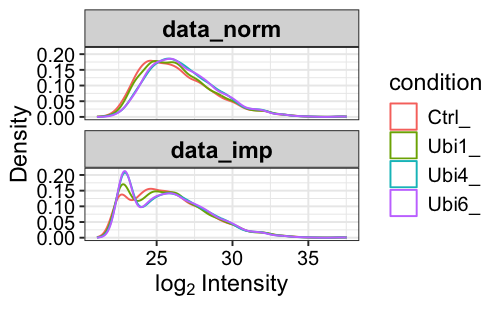

```r
plot_imputation(data_norm, data_imp)
```

*Differential Expression Analysis*

```r
library(limma)
data_diff <- test_diff(data_imp, type = "control", control = "Ctrl_") # apply Bayes statistics to compare all samples against control (Ctrl_); i.e. is there a significant difference between control and each condition?

data_diff_all_contrasts <- test_diff(data_imp, type = "all") # compare and contrast all sample combinations (*spider leg friction coefficient table), i.e. is there a significant difference *between each condition* in protein expression?
```

To identify the correct name/character string, use df$condition.

(Each individual control replicate (“Ctrl__1”, “Ctrl__2”, “Ctrl_*3”) does not need to be specified. Use ”Ctrl*” to group all 3 replicates for accurate df + sd + p-vals)

```r
#determine significant p-values (from control)
dep <- add_rejections(data_diff, alpha = 0.05, lfc = log2(1.5))
```

*Visualising the results*

PCA plot uses hierarchical clustering to group similar proteins together based on qualities, i.e. protein expression LFQ intensity

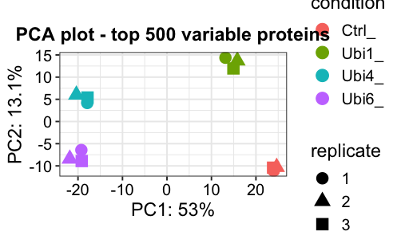

```r
plot_pca(dep)
```

```r
#differences in x-axis is more significant than that of vertical y-axis difference
```

Ubi6 and Ubi4 are the most different in overall protein expression compared to Ctrl. Ubi1 is similar in protein expression to Ctrl (PCA1) #elliptic shape: wide length holds most variance (PCA1), short length has least variance (PCA2), therefore differences in PCA1 take precedence

This is further supported by a Pearson correlation heatmap:

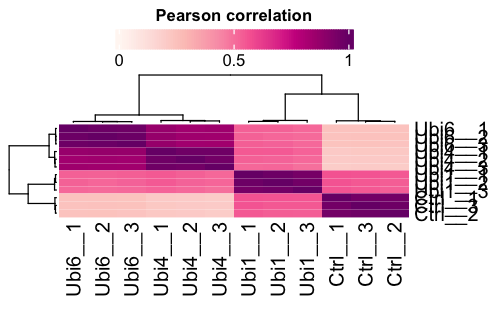

```r
plot_cor(dep, lower = 0, pal = "RdPu")
```

```r
#similar protein expression in Ubi6 and Ubi4 also reflected with a strong correlation in the heatmap
#weaker correlation in Ubi1 to Ctrl (strong PCA2, weak PCA1 difference)
```

Log fold intensity (log2 intensity) represents absolute abundance of a protein / expression; dataset is normalised (based on that protein’s expression average z-score). Log2 intensity used so that proteins with exponentially higher expression do not occlude the least expressed proteins.

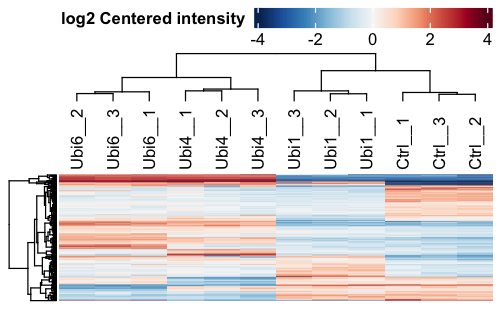

```r
#hierachical clustering heatmap (easier to view protein expression patterns across conditions/replicates)
plot_heatmap(dep, type = "centered", show_row_names = FALSE, col_limit= 4)
```

```r
# use kmeans = TRUE to group protein clusters of rows (specified no. with k = x)
```

#kmeans = FALSE uses hierarchical clustering: bottom-up approach joining 2 most similar proteins, then cluster with next pair of similar proteins etc…

Log fold change lfc represents changes in protein expression from control (contrasts). Does not tell you by how much, only relative difference in expression.

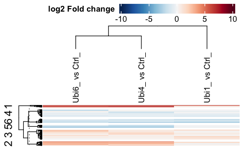

```r
plot_heatmap(dep, type = "contrast", kmeans = TRUE, col_limit = 10, show_row_names = FALSE)
```

#kmeans = TRUE uses k-means clustering: define number of clusters with k = x, then centroids (each cluster’s average) is chosen (distinct, least similar values to clearly define each cluster). Protein expression values most similar to a centroid will get regrouped. Each recruitment of a value recalculated the centroid average until all values have been assigned a cluster.

Volcano plots to visualise contrasts: changes in protein expression in one condition to another. x-axis = protein expression (contrast lfc), y-axis = p-value

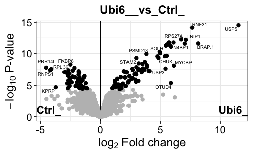

```r
plot_volcano(dep, contrast = "Ubi6__vs_Ctrl_", label_size = 2)
```

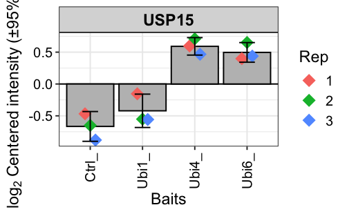

```r
#or select an individual protein:
plot_single(dep, proteins = "USP15", type = "centered")
```

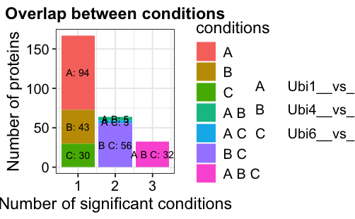

```r
#or visualise overall which proteins had significant protein expression + overlaps/similarities in proteins:
plot_cond(dep)
```